# Proyecto M1 - Modelo Baseline

NSW - Household goods retailing

Published

September 13, 2026

```r
library(fpp3)
mi_serie <- aus_retail |>
  filter(`Series ID` == "A3349397X")
mi_serie |> glimpse()
```

```
Rows: 441
Columns: 5
Key: State, Industry [1]
$ State       <chr> "New South Wales", "New South Wales", "New South Wales", "…
$ Industry    <chr> "Household goods retailing", "Household goods retailing", …
$ `Series ID` <chr> "A3349397X", "A3349397X", "A3349397X", "A3349397X", "A3349…
$ Month       <mth> 1982 Apr, 1982 May, 1982 Jun, 1982 Jul, 1982 Aug, 1982 Sep…
$ Turnover    <dbl> 211.3, 223.8, 215.7, 226.3, 217.1, 213.4, 223.5, 243.9, 39…
```

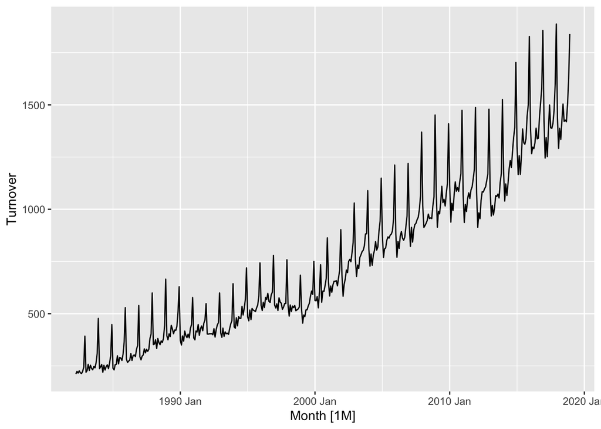

```r
mi_serie |> autoplot(Turnover)
```

La serie muestra una tendencia claramente creciente a lo largo de todo el periodo (1982-2020): el nivel de ventas sube de forma sostenida año con año.

También se observa un patrón que se repite cada diciembre, con un pico marcado por la temporada navideña, seguido de una caída en los meses posteriores.

Un punto importante es que el tamaño de estos picos de diciembre no se mantiene constante: al inicio de la serie las subidas son pequeñas, pero conforme el nivel general de la serie aumenta, los picos también se hacen más grandes. Esto indica que la variabilidad de la serie no es constante, sino que crece junto con el nivel de ventas. Por esta razón, antes de continuar con el análisis es necesario aplicar una transformación que estabilice esta variabilidad. (se necesita **estabilizar la varianza** con transformación log o Box-Cox antes de hacer la descomposición STL).

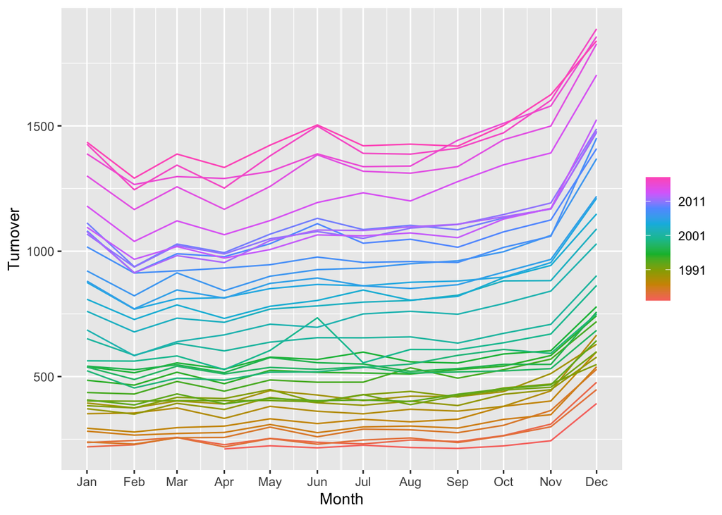

```r
mi_serie |> gg_season(Turnover)
```

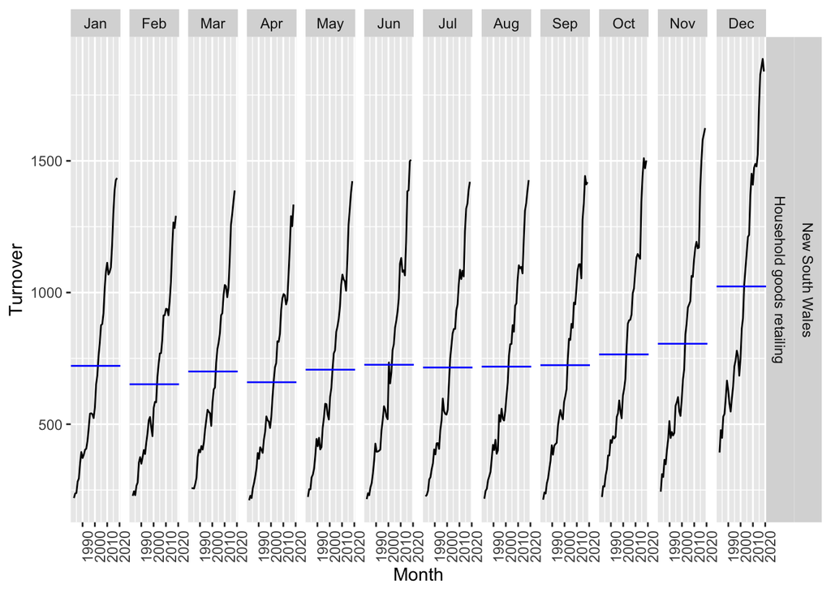

```r
mi_serie |> gg_subseries(Turnover)
```

El gráfico por subseries (gg_subseries) muestra que cada mes, por separado, tiene una tendencia creciente a lo largo del tiempo, y que el nivel promedio de diciembre (línea azul) es notablemente más alto que el de cualquier otro mes, confirmando a diciembre como el pico estacional de la serie.

```r
lambda <- mi_serie |>
  features(Turnover, guerrero) |>
  pull(lambda_guerrero)

lambda
```

```
[1] 0.4092002
```

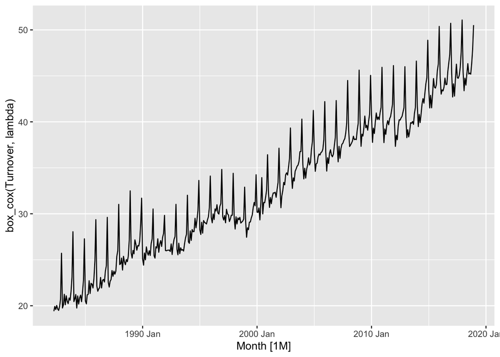

```r
mi_serie |>
  autoplot(box_cox(Turnover, lambda))
```

Para estabilizar la varianza se utilizó una transformación de Box-Cox, con el parámetro lambda seleccionado automáticamente mediante el método de Guerrero, obteniendo un valor de lambda = 0.409.

Al graficar la serie transformada se observa que el tamaño de los picos estacionales de diciembre ahora es consistente a lo largo de todo el periodo, a diferencia de la serie original donde estos picos crecían junto con el nivel de la serie. Esto confirma que la transformación corrigió adecuadamente el problema de varianza no constante.

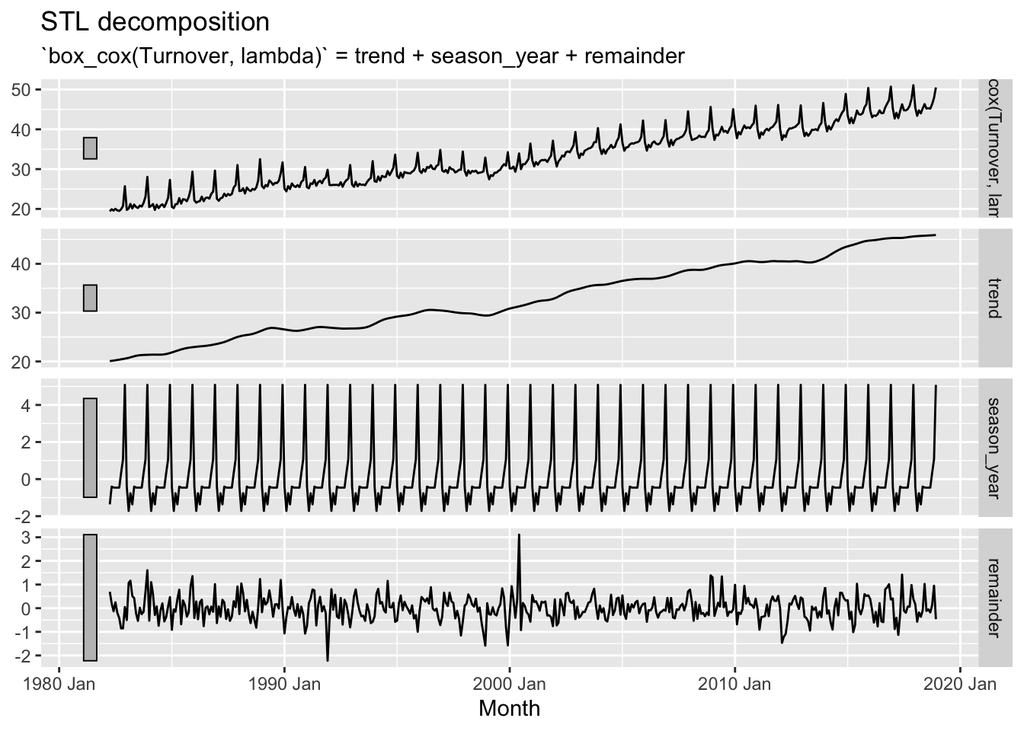

```r
mi_serie_dcmp <- mi_serie |>
  model(STL(box_cox(Turnover, lambda) ~ season(window = "periodic"),robust=TRUE))

mi_serie_dcmp |>
  components() |>
  autoplot()
```

Se aplicó una descomposición STL sobre la serie transformada, usando una ventana estacional periódica.

La componente de tendencia muestra un crecimiento suave y sostenido a lo largo de todo el periodo, sin señales de estacionalidad ni ruido. La componente estacional (season_year) muestra un patrón anual estable, con amplitud prácticamente constante. Finalmente, el remainder se comporta como ruido, sin un patrón sistemático evidente ni relación con la tendencia o la estacionalidad, salvo por algunos valores atípicos puntuales. Esto indica que la descomposición STL capturó adecuadamente la estructura de la serie.

```r
# División Train/Test (últimos 24 meses = test)
# slice() corta por POSICIÓN, (no por fecha)
# train = todo menos las últimas 24 filas
# test = esas 24 últimas

mi_serie_train <- mi_serie |>
  slice(1:(n() - 24))

mi_serie_test <- mi_serie |>
  slice((n() - 23):n())

# verificar quue el test debe tener exactamente 24 meses
mi_serie_test |> nrow()
```

```
[1] 24
```

```r
# Ajuste Estacional + Modelo Baseline (sólo train)
# decomposition_model() hace la descomposición y el pronóstico en un solo paso.
# se usa el mismo lambda que ya calculamos con guerrero()

ajuste_baseline <- mi_serie_train |>
  model(
    stl_snaive_rw = decomposition_model(

      # descomposición: separa tendencia+ruido de estacionalidad;sobre la serie ya transformada (varianza estable)
      STL(box_cox(Turnover, lambda) ~ season(window = "periodic")),

      # modelo para la parte ESTACIONAL (season_year)
      SNAIVE(season_year),

      # modelo para la parte AJUSTADA/sin estacionalidad (season_adjust)
      RW(season_adjust ~ drift())
    )
  )

# modelo ajustado
ajuste_baseline |> report()
```

```
Series: Turnover
Model: STL decomposition model
Transformation: box_cox(Turnover, lambda)
Combination: SNAIVE + RW w/ drift

=================================

Series: season_year
Model: SNAIVE

sigma^2: 0

Series: season_adjust
Model: RW w/ drift

Drift: 0.0598 (se: 0.0336)
sigma^2: 0.4683
```

Se ha dividido la serie en un conjunto de entrenamiento (todos los meses excepto los últimos 24) y un conjunto de prueba (los últimos 24 meses). Básicamente lo que se hizo fue que sobre el conjunto de entrenamiento se ajustó el modelo baseline, el cual combina una descomposición STL (sobre la serie transformada con Box-Co) con dos modelos:

SNAIVE() para pronosticar la componente estacional, y una caminata aleatoria con drift (RW con drift) para pronosticar la componente ajustada estacionalmente.

```r
# Hacemos el pronóstico en test (para evaluarlo)
forecast_test <- ajuste_baseline |>
  forecast(h = nrow(mi_serie_test))
# Ahora si evaluamos
accuracy_baseline <- forecast_test |>
  accuracy(mi_serie)

accuracy_baseline
```

```
# A tibble: 1 × 12
  .model State Industry .type    ME  RMSE   MAE   MPE  MAPE  MASE RMSSE     ACF1
  <chr>  <chr> <chr>    <chr> <dbl> <dbl> <dbl> <dbl> <dbl> <dbl> <dbl>    <dbl>
1 stl_s… New … Househo… Test  -67.5  80.8  72.1 -4.77  5.07  1.60  1.37 -0.00719
```

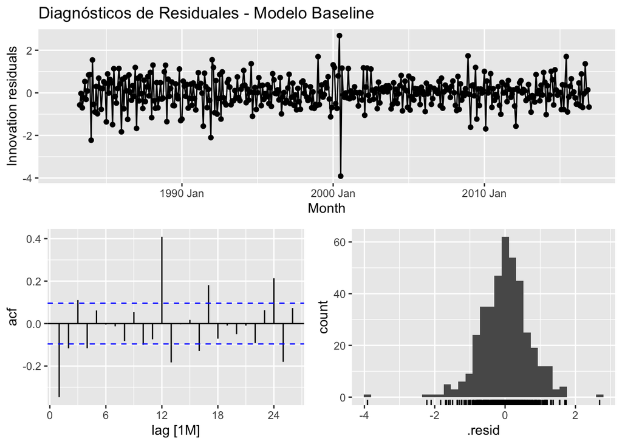

```r
ajuste_baseline |>
  select(stl_snaive_rw) |>
  gg_tsresiduals() +
  labs(title = "Diagnósticos de Residuales - Modelo Baseline")
```

```r
# Visualizamos la tabla de accuracy completa
accuracy_baseline |>
  select(.model, .type, RMSE, MAE, MAPE, MASE, RMSSE) |>
  knitr::kable(
    caption = "Métricas de precisión del modelo baseline en Train y Test",
    digits = 3
  )
```

| .model | .type | RMSE | MAE | MAPE | MASE | RMSSE |
| --- | --- | --- | --- | --- | --- | --- |
| stl_snaive_rw | Test | 80.801 | 72.104 | 5.073 | 1.6 | 1.366 |

```r
# Reentrenamos con toda la serie
modelo_final <- mi_serie |>
  model(
    stl_snaive_rw = decomposition_model(
      STL(box_cox(Turnover, lambda) ~ season(window = "periodic")),
      SNAIVE(season_year),
      RW(season_adjust ~ drift())
    )
  )

modelo_final |> report()
```

```
Series: Turnover
Model: STL decomposition model
Transformation: box_cox(Turnover, lambda)
Combination: SNAIVE + RW w/ drift

=================================

Series: season_year
Model: SNAIVE

sigma^2: 0

Series: season_adjust
Model: RW w/ drift

Drift: 0.056 (se: 0.0329)
sigma^2: 0.4752
```

```r
# pronóstico a 24 meses
forecast_24 <- modelo_final |>
  forecast(h = 24)

forecast_24
```

```
# A fable: 24 x 6 [1M]
# Key:     State, Industry, .model [1]
   State           Industry                 .model    Month       Turnover .mean
   <chr>           <chr>                    <chr>     <mth>         <dist> <dbl>
 1 New South Wales Household goods retaili… stl_s… 2019 Jan t(N(45, 0.48)) 1416.
 2 New South Wales Household goods retaili… stl_s… 2019 Feb t(N(44, 0.95)) 1326.
 3 New South Wales Household goods retaili… stl_s… 2019 Mar  t(N(45, 1.4)) 1398.
 4 New South Wales Household goods retaili… stl_s… 2019 Apr  t(N(44, 1.9)) 1356.
 5 New South Wales Household goods retaili… stl_s… 2019 May  t(N(45, 2.4)) 1431.
 6 New South Wales Household goods retaili… stl_s… 2019 Jun  t(N(45, 2.9)) 1444.
 7 New South Wales Household goods retaili… stl_s… 2019 Jul  t(N(45, 3.4)) 1437.
 8 New South Wales Household goods retaili… stl_s… 2019 Aug  t(N(45, 3.9)) 1443.
 9 New South Wales Household goods retaili… stl_s… 2019 Sep  t(N(46, 4.4)) 1449.
10 New South Wales Household goods retaili… stl_s… 2019 Oct  t(N(46, 4.9)) 1512.
# ℹ 14 more rows
```

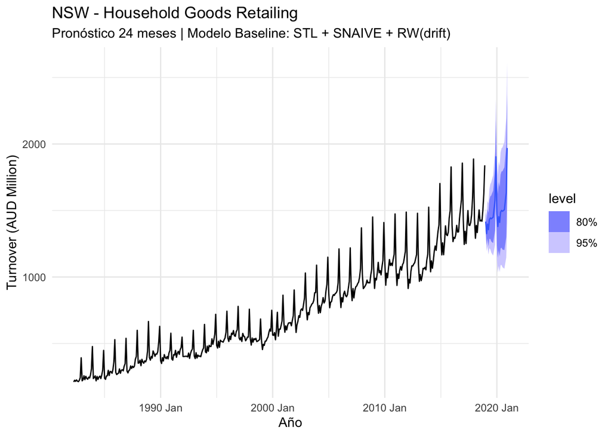

```r
# graficamos el pronóstico
forecast_24 |>
  autoplot(mi_serie) +
  labs(
    title = "NSW - Household Goods Retailing",
    subtitle = "Pronóstico 24 meses | Modelo Baseline: STL + SNAIVE + RW(drift)",
    y = "Turnover (AUD Million)",
    x = "Año"
  ) +
  theme_minimal()
```

```r
# tabla de pronósticos
forecast_24 |>
  as_tibble() |>
  select(Month, .mean) |>
  rename("Período" = Month, "Pronóstico" = .mean) |>
  knitr::kable(
    caption = "Pronóstico a 24 meses",
    digits = 2
  )
```

Pronóstico a 24 meses

| Período | Pronóstico |
| --- | --- |
| 2019 Jan | 1416.38 |
| 2019 Feb | 1325.61 |
| 2019 Mar | 1397.92 |
| 2019 Apr | 1355.68 |
| 2019 May | 1430.95 |
| 2019 Jun | 1444.16 |
| 2019 Jul | 1437.30 |
| 2019 Aug | 1443.45 |
| 2019 Sep | 1449.03 |
| 2019 Oct | 1512.01 |
| 2019 Nov | 1574.80 |
| 2019 Dec | 1903.78 |
| 2020 Jan | 1472.29 |
| 2020 Feb | 1379.58 |
| 2020 Mar | 1453.47 |
| 2020 Apr | 1410.35 |
| 2020 May | 1487.25 |
| 2020 Jun | 1500.76 |
| 2020 Jul | 1493.77 |
| 2020 Aug | 1500.08 |
| 2020 Sep | 1505.80 |
| 2020 Oct | 1570.11 |
| 2020 Nov | 1634.22 |
| 2020 Dec | 1969.66 |

El modelo baseline reentrenado en la serie completa genera un pronóstico a 24 meses que mantiene la tendencia creciente observada históricamente y preserva el patrón estacional característico (picos en diciembre). Los intervalos de confianza del 80% y 95% se ensanchan progresivamente hacia el horizonte, reflejando apropiadamemte el aumento de incertidumbre a medida que se aleja del final de la serie.